# D6_Apresentacao

Antonio Carvalho Feitosa

6 de outubro de 2018

### Construindo a apresenta??o

```r
### INTRODU??O

### ANTECEDENTES E CONTEXTO

### OBTEN??O E TRATAMENTO DOS DADOS

### RESULTADOS E DISCUSS?O

### CONSIDERA??ES FINAIS

### REFER?NCIAS
```

```r
dados <- read.csv("https://raw.githubusercontent.com/cursoRunb/cursoENAP2018/master/Aula5/dadosAlunos/antonio/ANTONIO_areairrig1995pib.csv", sep =";", encoding ="latin1")
head(dados)
```

```
##       id    latitude longitude           municipio uf area1000ha pib2000
## 1 140010  282.384000  -606.753           Boa Vista RR          5    1223
## 2 160027   -0.804911   -52.453    Laranjal do Jari AP          9      92
## 3 170730 -113.416000  -492.716               Dueré TO         13      22
## 4 170820 -117.976000  -495.316 Formoso do Araguaia TO         29     126
## 5 171190 -107.906000  -496.199   Lagoa da Confusão TO         11      42
## 6 230760 -514.392000  -380.847   Limoeiro do Norte CE          6     113
##   pib2005 pib2010 pib2015
## 1    2265    5123    7559
## 2     184     347     560
## 3      43      56     116
## 4     178     215     357
## 5     128     170     449
## 6     270     506     816
```

```r
tail(dados)
```

```
##         id latitude longitude             municipio uf area1000ha pib2000
## 95  500720 -218.033  -545.427         Rio Brilhante MS          7     177
## 96  500793 -175.698  -547.551                Sonora MS          6     119
## 97  510263 -136.587  -578.907 Campo Novo do Parecis MT         48     362
## 98  520860 -153.118  -491.162             Goianésia GO          8     175
## 99  521170 -170.481  -501.453               Jandaia GO          6      54
## 100 530010 -157.795  -479.297              Brasília DF         13   46475
##     pib2005 pib2010 pib2015
## 95      295    1039    1682
## 96      159     314     589
## 97     1053    1026    2111
## 98      451     677    1098
## 99      141     147     192
## 100   80527  144174  215613
```

```r
head(dados[order(dados$area1000ha, decreasing = TRUE),])
```

```
##        id latitude longitude               municipio uf area1000ha pib2000
## 90 432240 -297.614  -570.853              Uruguaiana RS         93     707
## 70 431060 -291.311  -565.515                  Itaqui RS         67     294
## 82 431730  -33.525  -533.717 Santa Vitória do Palmar RS         50     178
## 84 431800 -286.578  -560.036               São Borja RS         48     332
## 97 510263 -136.587  -578.907   Campo Novo do Parecis MT         48     362
## 57 430040 -297.902  -557.949                Alegrete RS         46     407
##    pib2005 pib2010 pib2015
## 90    1651    1519    2625
## 70     486     686    1164
## 82     289     451     834
## 84     690     982    1613
## 97    1053    1026    2111
## 57     745    1064    1820
```

```r
head(dados[order(dados$pib2015, decreasing = TRUE),])
```

```
##         id latitude longitude             municipio uf area1000ha pib2000
## 100 530010 -157.795  -479.297              Brasília DF         13   46475
## 35  330100 -217.622  -413.181 Campos dos Goytacazes RJ         26    5645
## 1   140010  282.384  -606.753             Boa Vista RR          5    1223
## 74  431440 -317.649  -523.371               Pelotas RS         14    1683
## 93  500370 -222.231   -54.812              Dourados MS          5    1023
## 77  431560 -320.349  -521.071            Rio Grande RS         13    1850
##     pib2005 pib2010 pib2015
## 100   80527  144174  215613
## 35    16653   38684   34217
## 1      2265    5123    7559
## 74     2629    4228    7390
## 93     1807    3765    7284
## 77     3015    5143    7275
```

### Atribuindo e organizando os dados para an?lise.

```r
dados2015pib <- dados[order(dados$pib2015, decreasing = TRUE),]
nrow(dados2015pib)
```

```
## [1] 100
```

```r
head(dados2015pib)
```

```
##         id latitude longitude             municipio uf area1000ha pib2000
## 100 530010 -157.795  -479.297              Brasília DF         13   46475
## 35  330100 -217.622  -413.181 Campos dos Goytacazes RJ         26    5645
## 1   140010  282.384  -606.753             Boa Vista RR          5    1223
## 74  431440 -317.649  -523.371               Pelotas RS         14    1683
## 93  500370 -222.231   -54.812              Dourados MS          5    1023
## 77  431560 -320.349  -521.071            Rio Grande RS         13    1850
##     pib2005 pib2010 pib2015
## 100   80527  144174  215613
## 35    16653   38684   34217
## 1      2265    5123    7559
## 74     2629    4228    7390
## 93     1807    3765    7284
## 77     3015    5143    7275
```

```r
tail(dados2015pib)
```

```
##        id latitude longitude         municipio uf area1000ha pib2000
## 58 430085 -309.092  -515.046          Arambaré RS         11      26
## 3  170730 -113.416  -492.716             Dueré TO         13      22
## 85 431830 -303.337  -543.217       São Gabriel RS         38      22
## 36 350500 -236.284  -495.634 Barão de Antonina SP          6      10
## 80 431690 -296.868  -538.149       Santa Maria RS         12       6
## 52 355170 -211.316  -479.875       Sertãozinho SP          6       6
##    pib2005 pib2010 pib2015
## 58      39      67     130
## 3       43      56     116
## 85      42      69     113
## 36      17      25      71
## 80      13      22      58
## 52      13      24      40
```

### Imprimindo o gr?fico de pontos, observa-se claramente que existem 2 (dois) $outliers$: Bras?lia-DF e Campos dos Goytacazes-RJ.

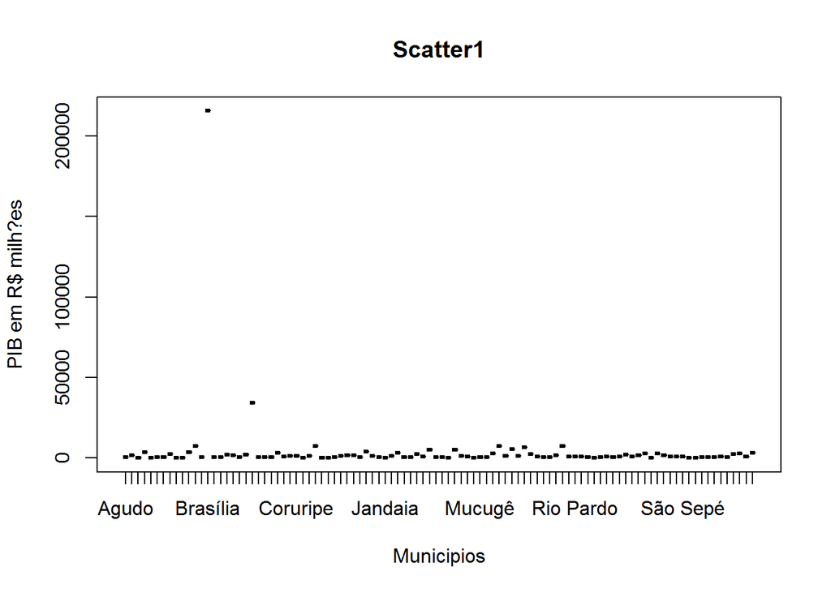

```r
plot(dados2015pib$municipio,dados2015pib$pib2015,
     xlab = "Municipios", ylab = "PIB em R$ milh?es", main = "Scatter1")
```

### Identificando outliers: Bras?lia-DF, Campos dos Goytacazes-RJ e Boa Vista-RR

```r
outleir <- c("Brasilia", "Campos_dos_Goytacazes", "Boa_Vista")
outleir
```

```
## [1] "Brasilia"              "Campos_dos_Goytacazes" "Boa_Vista"
```

```r
agropecuaria <- c(0.3, 0.3, 7.0)
agropecuaria
```

```
## [1] 0.3 0.3 7.0
```

```r
adm_publica <- c(44.7, 5.7, 48.0)
adm_publica
```

```
## [1] 44.7  5.7 48.0
```

```r
com_ind_serv <- c(39.9, 94.0, 37.0)
com_ind_serv
```

```
## [1] 39.9 94.0 37.0
```

```r
outros <- c(15.1, 0.0, 8.0)
outros
```

```
## [1] 15.1  0.0  8.0
```

```r
Outleirs <- data.frame(outleir, agropecuaria, adm_publica, com_ind_serv, outros)
Outleirs
```

```
##                 outleir agropecuaria adm_publica com_ind_serv outros
## 1              Brasilia          0.3        44.7         39.9   15.1
## 2 Campos_dos_Goytacazes          0.3         5.7         94.0    0.0
## 3             Boa_Vista          7.0        48.0         37.0    8.0
```

### Excluindo esses 3 (tr?s) munic?pios, considerados **outleirs** passei a analisar os dados dos outros 97 munic?pios.

```r
pib2015A <- dados2015pib
nrow(pib2015A)
```

```
## [1] 100
```

```r
head(pib2015A)
```

```
##         id latitude longitude             municipio uf area1000ha pib2000
## 100 530010 -157.795  -479.297              Brasília DF         13   46475
## 35  330100 -217.622  -413.181 Campos dos Goytacazes RJ         26    5645
## 1   140010  282.384  -606.753             Boa Vista RR          5    1223
## 74  431440 -317.649  -523.371               Pelotas RS         14    1683
## 93  500370 -222.231   -54.812              Dourados MS          5    1023
## 77  431560 -320.349  -521.071            Rio Grande RS         13    1850
##     pib2005 pib2010 pib2015
## 100   80527  144174  215613
## 35    16653   38684   34217
## 1      2265    5123    7559
## 74     2629    4228    7390
## 93     1807    3765    7284
## 77     3015    5143    7275
```

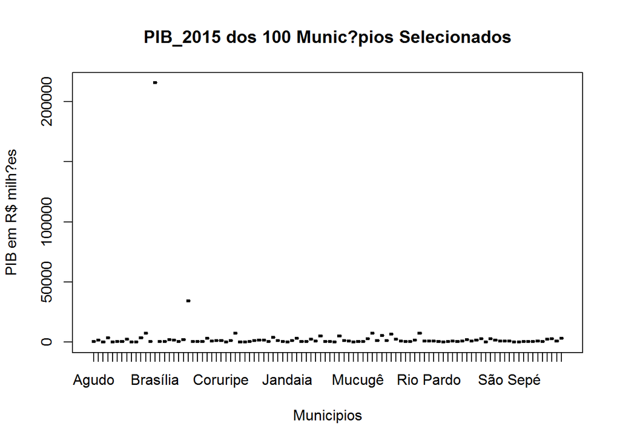

```r
plot(pib2015A$municipio,pib2015A$pib2015, xlab = "Municipios", ylab = "PIB em R$ milh?es", main = "PIB_2015 dos 100 Munic?pios Selecionados")
```

### Imprimindo o *boxplot* do PIB dos 100 munic?pios selecionados.

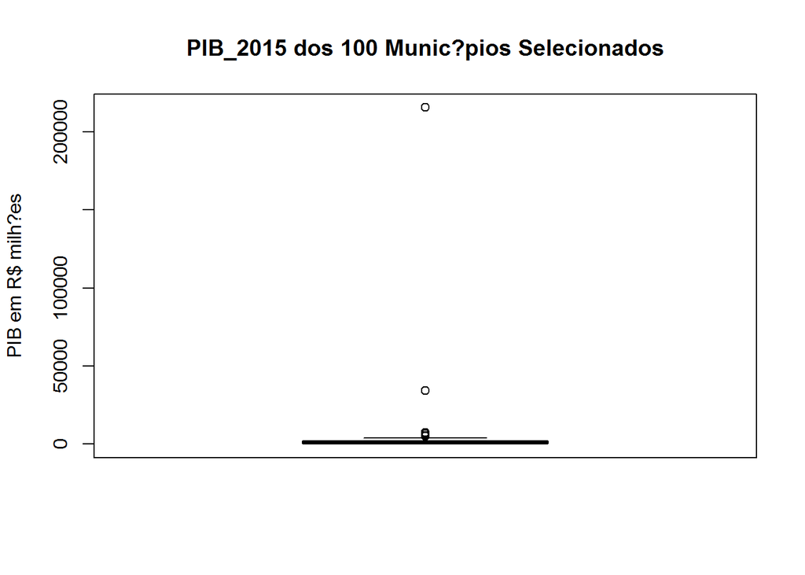

```r
boxplot(pib2015A$pib2015, ylab = "PIB em R$ milh?es", main = "PIB_2015 dos 100 Munic?pios Selecionados")
```

### Excluindo *outileirs* para an?lise dos dados.

```r
pib2015B <- pib2015A[4:100,]
nrow(pib2015B)
```

```
## [1] 97
```

```r
head(pib2015B)
```

```
##        id latitude longitude       municipio uf area1000ha pib2000 pib2005
## 74 431440 -317.649  -523.371         Pelotas RS         14    1683    2629
## 93 500370 -222.231   -54.812        Dourados MS          5    1023    1807
## 77 431560 -320.349  -521.071      Rio Grande RS         13    1850    3015
## 47 353800 -229.246  -454.613 Pindamonhangaba SP         22    1305    2611
## 9  261110 -938.866  -405.027       Petrolina PE         16     725    1670
## 32 320320 -193.946  -400.643        Linhares ES         14     742    1402
##    pib2010 pib2015
## 74    4228    7390
## 93    3765    7284
## 77    5143    7275
## 47    3856    6641
## 9     3434    5534
## 32    3275    5239
```

### Gerando o gr?fico de pontos para os 97 munic?pios selecionados.

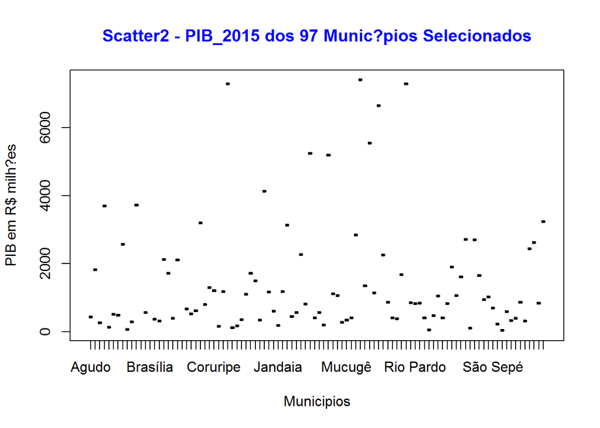

```r
plot(pib2015B$municipio,pib2015B$pib2015,
     xlab = "Municipios", ylab = "PIB em R$ milh?es",
     main = "Scatter2 - PIB_2015 dos 97 Munic?pios Selecionados",
     col.main = "blue"
     )
```

### Gerando o *boxplot* para os 97 munic?pios selecionados

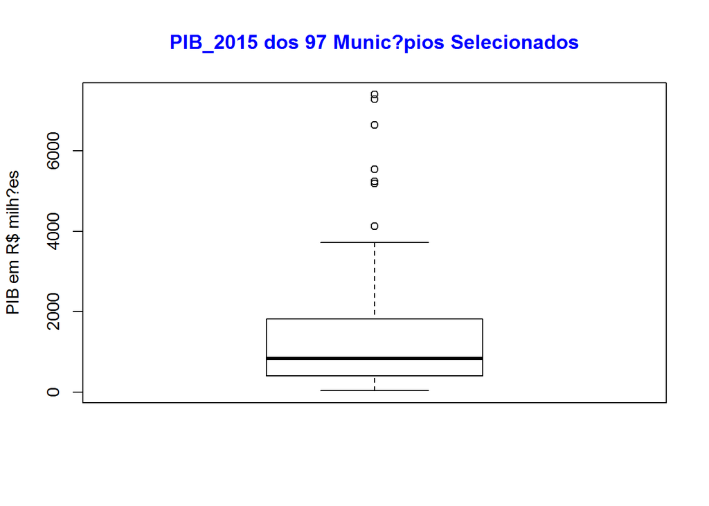

```r
boxplot(pib2015B$pib2015, ylab = "PIB em R$ milh?es",
        main = "PIB_2015 dos 97 Munic?pios Selecionados",
        col.main = "blue"
        )
```

### Atualizando os valores de PIB para an?lise

```r
AA <- sum(pib2015B$pib2000)
AA
```

```
## [1] 28173
```

```r
BB <- sum(pib2015B$pib2005)
BB
```

```
## [1] 51507
```

```r
CC <- sum(pib2015B$pib2010)
CC
```

```
## [1] 83894
```

```r
DD <- sum(pib2015B$pib2015)
DD
```

```
## [1] 142985
```

```r
pib2000_2015 <- c(AA,BB,CC,DD)
pib2000_2015
```

```
## [1]  28173  51507  83894 142985
```

### Atualizando pelo INPC os valores de PIB dos 97 munic?pios selecionados dos anos 2000, 2005, 2010 e 2015 at? 30 de junho de 2018

```r
atualiza <- c(3.1101, 2.0095, 1.5779, 1.1258)
atualiza
```

```
## [1] 3.1101 2.0095 1.5779 1.1258
```

```r
pib2000_2015 <- pib2000_2015*atualiza
pib2000_2015
```

```
## [1]  87620.85 103503.32 132376.34 160972.51
```

```r
pibMunicipios <- pib2000_2015
pibMunicipios
```

```
## [1]  87620.85 103503.32 132376.34 160972.51
```

### Atribuindo e atualizando pelo INPC os valores de PIB do Brasil nos anos 2000, 2005, 2010 e 2015 at? 30 de junho de 2018

```r
pibBR <- c(1199092, 2170585, 3885847, 6000570)
pibBR
```

```
## [1] 1199092 2170585 3885847 6000570
```

```r
pibBRatual <- pibBR*atualiza
pibBRatual
```

```
## [1] 3729296 4361791 6131478 6755442
```

```r
pibBrasil <- pibBRatual
pibBrasil
```

```
## [1] 3729296 4361791 6131478 6755442
```

### Calculando a rela??o entre 2015 e 2000 (pibMunicipios/pibBrasil)

```r
razaoPIB <- 100*(pibMunicipios/pibBrasil)
razaoPIB
```

```
## [1] 2.349528 2.372955 2.158963 2.382857
```

### Calculando a varia??o entre 2015 e 2000 (pibMunicipios/pibBrasil)

```r
variacao <- razaoPIB[4]/razaoPIB[1]
variacao
```

```
## [1] 1.014185
```

```r
Anos <- c(2000, 2005, 2010, 2015)
Anos
```

```
## [1] 2000 2005 2010 2015
```

```r
tabela <- data.frame(Anos, pibBrasil, pibMunicipios)
tabela
```

```
##   Anos pibBrasil pibMunicipios
## 1 2000   3729296      87620.85
## 2 2005   4361791     103503.32
## 3 2010   6131478     132376.34
## 4 2015   6755442     160972.51
```